# Assignment 4

Magee Ying

16/05/2022

```css
@import url('https://fonts.googleapis.com/css2?family=Macondo&family=Oswald:wght@200&display=swap');

h1 {font-family: 'Macondo', cursive;}
body {font-family: 'Oswald', sans-serif;;
      background-color: #e9f0e9}
```

## Introduction

For this assignment, I am interested in whether the tempo of a Spotify playlist correlates with the energy of the Spotify playlist over years. We will achieve this by extracting the variables tempo and energy from their data frames, creating a graph of it, and finally putting the year into an animated graph.

## Procedures

### Loading in our data

For our first step, we want to load our data frame from a JSON file, into a variable called spotify_data.

```r
spotify_data <- fromJSON("jnso6281bfcd9f797.json")
```

### Extracting the variables and making a regression line

Secondly, we want to find out the relationship between the variables tempo and energy, thus we arranged the data as tempo with ascending order, then we plotted it in a scatter plot against its corresponding energy. By doing so we can create a scatter plot to see if there are any relations between the two variables. After this is achieved, we want to be able to visualize the data we have created by inserting a regression line.

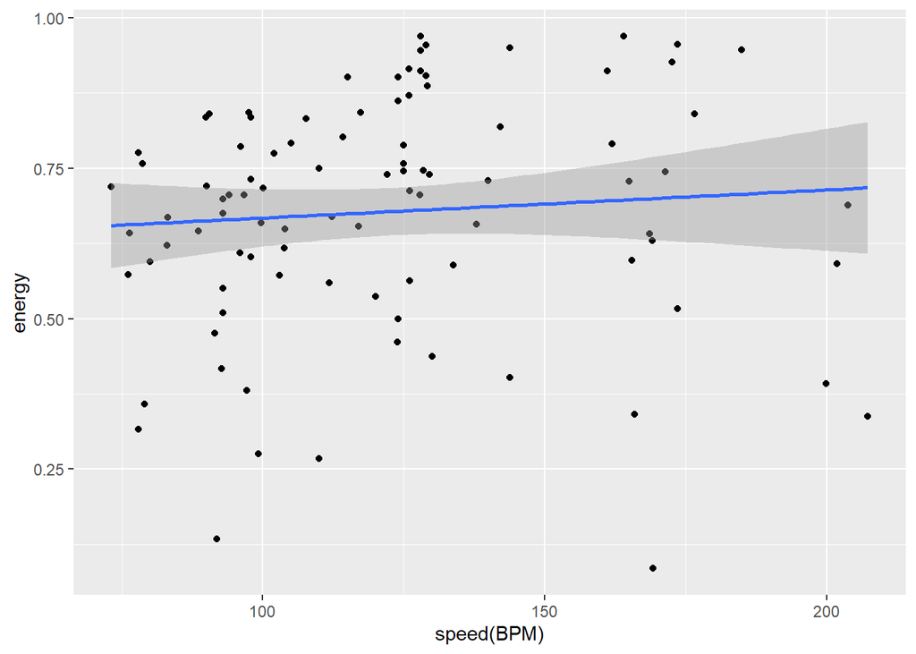

```r
speed_data <- spotify_data %>%
  arrange(tempo)

p <- ggplot(speed_data, aes(tempo, energy), color = "blue") +
  geom_point()

p + geom_smooth(method = lm) +
  labs(x = "speed(BPM)")
```

As we can see from the graph above, there is somewhat a weak relationship between the playlist’s tempo and its energy level.

### Creating the animated graph

For this section, we would want to animate the graph based on its year, and by doing so, we will have a clear understanding of how the relationship between energy and speed of a playlist changes each year. We have to make two time periods, one before 2005 and one after 2005 because I am interested in how the relationship changed from 17 years ago.

```r
year_data <- speed_data %>%
  separate_rows(release_date, sep = "-") %>%
  filter(nchar(release_date) > 3) %>%
  mutate(year = as.numeric(release_date)) %>%
  mutate(period = ifelse(year < 2005, "before 2005", "2005 and after")) %>%
  print()
```

```
## # A tibble: 95 x 25
##    playlist_id            playlist_name  track_id  track_name   track_popularity
##    <chr>                  <chr>          <chr>     <chr>                   <int>
##  1 515RogjKGjVSDjpJONs8Kl STATS220 birt~ 4CZgaNdo~ Witches                    58
##  2 515RogjKGjVSDjpJONs8Kl STATS220 birt~ 3TCauNPq~ Beautiful                  68
##  3 515RogjKGjVSDjpJONs8Kl STATS220 birt~ 5TAf4lnZ~ I Try                      70
##  4 515RogjKGjVSDjpJONs8Kl STATS220 birt~ 7zw9OxtV~ Eternity                   47
##  5 515RogjKGjVSDjpJONs8Kl STATS220 birt~ 5xEM5hIg~ Complicated                77
##  6 515RogjKGjVSDjpJONs8Kl STATS220 birt~ 2D1hlMwW~ P.I.M.P.                   67
##  7 515RogjKGjVSDjpJONs8Kl STATS220 birt~ 5MoDQWMD~ Eternal Fla~               65
##  8 515RogjKGjVSDjpJONs8Kl STATS220 birt~ 751gBcu6~ Thank You                  60
##  9 515RogjKGjVSDjpJONs8Kl STATS220 birt~ 4PMaLoxX~ Two Wrongs ~               34
## 10 515RogjKGjVSDjpJONs8Kl STATS220 birt~ 7I1fHMDN~ Turn Your L~               62
## # ... with 85 more rows, and 20 more variables: track_album_name <chr>,
## #   release_date <chr>, artist_name <chr>, artist_genre <chr>,
## #   danceability <dbl>, energy <dbl>, key_name <chr>, loudness <dbl>,
## #   mode_name <chr>, speechiness <dbl>, acousticness <dbl>,
## #   instrumentalness <dbl>, liveness <dbl>, valence <dbl>, tempo <dbl>,
## #   time_signature <int>, duration_ms <int>, explicit <lgl>, year <dbl>,
## #   period <chr>
```

From the above, we have obtained the data frame, year_data, which contains the data we need to animate the graph.

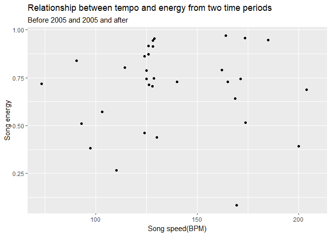

```r
plot <- ggplot(year_data,
              aes(x = tempo, y = energy), color = "red") +
  geom_point() +
  transition_states(period,
                    transition_length = 5,
                    state_length = 5) +
  ggtitle("Relationship between tempo and energy from two time periods",
          subtitle = "Before 2005 and 2005 and after") +
  labs(x = "Song speed(BPM)", y = "Song energy")

animate(plot, nframe = 5, fps = 1)
```

For this graph, I have made two time periods, one is before 2005, and the other is 2005 and later. I tried to insert a line of regression for both time periods on the animated graph, but it was unsuccessful, I also tried to insert more time periods by using the mutate() and ifelse() functions, but I could not have it work, therefore I ended up with only two time periods.